# R Notebook

# Introduzione

Librerie

```r
library(lme4)
library(tidyverse)
library(RColorBrewer)
library(lmerTest)
library(gamlss)
```

# Descrizione del dataset

```r
load("DataRegression2025_unical.RData")
data=data.frame(RiceFarms)
data$id = as.factor(data$id)
attach(data)
```

[output not shown]

```r
which(is.na(data)) #non ci sono missing value.
```

```
integer(0)
```

```r
head(data)
```

|  | id | size | status | varieties | bimas | seed | urea | phosphate | pesticide | pseed | purea | pphosph | hiredlabor | famlabor | totlabor | wage | goutput | noutput | price | region |
| --- | --- | --- | --- | --- | --- | --- | --- | --- | --- | --- | --- | --- | --- | --- | --- | --- | --- | --- | --- | --- |
| 1 | 101001 | 3.000 | owner | mixed | mixed | 90 | 900 | 80 | 6000 | 80 | 75 | 75 | 2875 | 40 | 2915 | 68.49 | 7980 | 6800 | 60 | wargabinangun |
| 2 | 101001 | 2.000 | owner | trad | mixed | 40 | 600 | 0 | 3000 | 70 | 75 | 75 | 2110 | 45 | 2155 | 60.09 | 4083 | 3500 | 60 | wargabinangun |
| 3 | 101001 | 1.000 | owner | high | mixed | 100 | 700 | 150 | 5000 | 140 | 70 | 70 | 980 | 95 | 1075 | 51.99 | 2650 | 2242 | 65 | wargabinangun |
| 4 | 101001 | 2.000 | owner | high | mixed | 60 | 600 | 100 | 5000 | 90 | 70 | 70 | 2081 | 10 | 2091 | 56.98 | 4500 | 3750 | 70 | wargabinangun |
| 5 | 101001 | 3.572 | share | high | no | 105 | 400 | 400 | 10200 | 350 | 80 | 80 | 3889 | 1 | 3889 | 152.03 | 16300 | 13584 | 120 | wargabinangun |
| 6 | 101001 | 3.572 | share | high | no | 105 | 400 | 400 | 10200 | 250 | 80 | 80 | 3519 | 1 | 3519 | 154.49 | 17424 | 14520 | 140 | wargabinangun |

```r
str(data)
```

```
'data.frame':   1026 obs. of  20 variables:
 $ id        : Factor w/ 171 levels "101001","101017",..: 1 1 1 1 1 1 2 2 2 2 ...
 $ size      : num  3 2 1 2 3.57 ...
 $ status    : Factor w/ 3 levels "owner","share",..: 1 1 1 1 2 2 3 3 3 1 ...
 $ varieties : Factor w/ 3 levels "trad","high",..: 3 1 2 2 2 2 1 2 2 3 ...
 $ bimas     : Factor w/ 3 levels "no","yes","mixed": 3 3 3 3 1 1 3 3 3 1 ...
 $ seed      : int  90 40 100 60 105 105 50 20 15 7 ...
 $ urea      : int  900 600 700 600 400 400 120 100 150 50 ...
 $ phosphate : int  80 0 150 100 400 400 0 0 50 0 ...
 $ pesticide : int  6000 3000 5000 5000 10200 10200 0 0 900 0 ...
 $ pseed     : num  80 70 140 90 350 250 60 50 130 150 ...
 $ purea     : num  75 75 70 70 80 80 75 75 70 70 ...
 $ pphosph   : num  75 75 70 70 80 80 75 75 70 70 ...
 $ hiredlabor: int  2875 2110 980 2081 3889 3519 670 805 380 40 ...
 $ famlabor  : int  40 45 95 10 1 1 140 50 80 69 ...
 $ totlabor  : int  2915 2155 1075 2091 3889 3519 810 855 460 109 ...
 $ wage      : num  68.5 60.1 52 57 152 ...
 $ goutput   : int  7980 4083 2650 4500 16300 17424 3840 2800 950 240 ...
 $ noutput   : int  6800 3500 2242 3750 13584 14520 3200 2400 800 200 ...
 $ price     : num  60 60 65 70 120 140 60 50 62 60 ...
 $ region    : Factor w/ 6 levels "wargabinangun",..: 1 1 1 1 1 1 1 1 1 1 ...
```

```r
names(data)
```

```
 [1] "id"         "size"       "status"     "varieties"  "bimas"      "seed"       "urea"       "phosphate"  "pesticide"  "pseed"      "purea"      "pphosph"
[13] "hiredlabor" "famlabor"   "totlabor"   "wage"       "goutput"    "noutput"    "price"      "region"
```

### Descrizioni variabili

- id: identificativo univoco dell’azienda agricola.

-1 CARATTERISTICHE DEL TERRENO: SUDDIVISE IN ETTARI COLTIVATI E PROPRIETA’ DEL TERRENO

-size: area totale coltivata a riso (in ettari). -status: stato della terra coltivata, che può essere: -owner: agricoltori proprietari o affittuari (non mezzadri). -share: mezzadri. -mixed: combinazione delle due categorie precedenti.

Y$varieties varieties: tipo di varietà di riso coltivate: trad: varietà tradizionali. -high: varietà ad alta resa. mixed: combinazione delle due varietà. bimas: partecipazione al programma di intensificazione BIMAS: no: non partecipante. yes: partecipante. mixed: solo una parte del terreno è registrata nel programma.

FATTORI DI INPUT PRODUTTIVI: COSTO DELLE MATERIE PRIME E TIPOLOGIA

seed: quantità di semi utilizzati (kg). urea: quantità di urea utilizzata (kg). phosphate: quantità di fosfato utilizzata (kg). pesticide: costo dei pesticidi (in Rupiah). pseed: prezzo del seme (in Rupiah per kg). purea: prezzo dell’urea (in Rupiah per kg). pphosph: prezzo del fosfato (in Rupiah per kg).

INPUT: COSTI DEL PERSONALE E ORE DI LAVORO hiredlabor: ore di lavoro salariato. famlabor: ore di lavoro familiare. totlabor: totale ore di lavoro (escludendo il raccolto). wage: salario della manodopera (in Rupiah per ora).

PRODUZIONE LORDA E NETTA goutput: produzione lorda di riso (kg). noutput: produzione netta di riso, calcolata sottraendo il costo del raccolto dalla produzione lorda. price: prezzo del riso grezzo (in Rupiah per kg).

AREE GEOGRAFICHE IN CUI OPERANO LE AZIENDE: region: area geografica di appartenenza dell’azienda agricola, tra: wargabinangun, langan, gunungwangi, malausma, sukaambit, ciwangi.

# Analisi

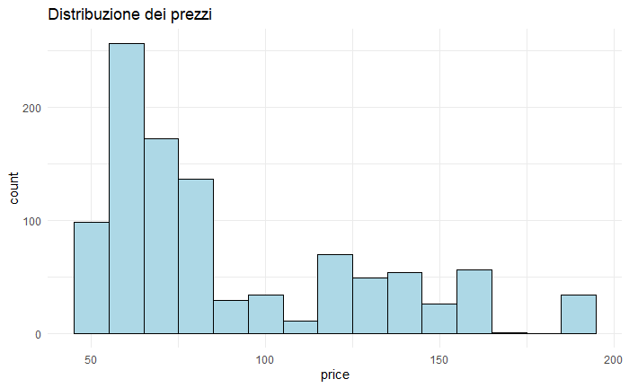

```r
ggplot(data, aes(x = price)) +
  geom_histogram(binwidth = 10, fill = "lightblue", color = "black") +
  theme_minimal() +
  labs(title = "Distribuzione dei prezzi")
```

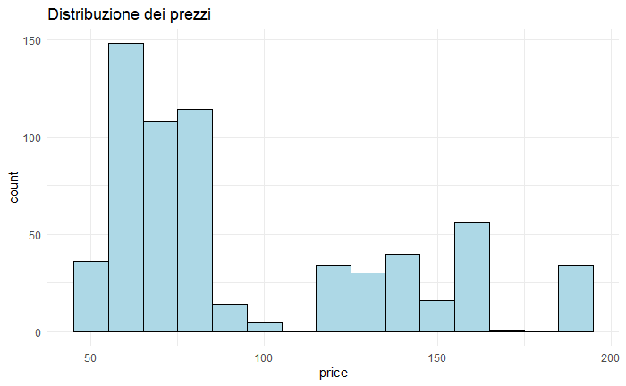

```r
data_rich <- data %>%
  filter(region %in% c("gunungwangi", "malausma", "ciwangi"))

ggplot(data_rich, aes(x = price)) +
  geom_histogram(binwidth = 10, fill = "lightblue", color = "black") +
  theme_minimal() +
  labs(title = "Distribuzione dei prezzi")
```

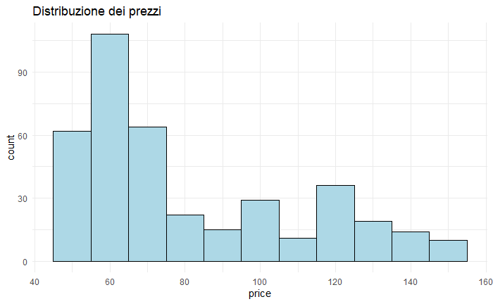

```r
data_p = subset(data, !region %in% c("gunungwangi", "malausma", "ciwangi"))

ggplot(data_p, aes(x = price)) +
  geom_histogram(binwidth = 10, fill = "lightblue", color = "black") +
  theme_minimal() +
  labs(title = "Distribuzione dei prezzi")
```

```r
sort(unique(data$price))
```

```
 [1]  50.00  52.00  55.00  56.00  58.00  60.00  62.00  63.00  64.00  65.00  66.00  67.00  68.00  70.00  72.00  73.00  75.00  78.00  80.00  81.00  83.00  84.00  85.00
[24]  88.00  89.00  90.00  92.00  95.00  96.00  97.00 100.00 101.00 104.00 110.00 115.00 120.00 125.00 130.00 135.00 137.00 140.00 140.23 142.36 145.00 145.83 150.00
[47] 156.00 160.00 168.48 187.50 190.00
```

```r
model.1<-lmer(price~1 + pseed + purea + wage + (1|id), data=data)
summary(model.1)
```

```
Linear mixed model fit by REML. t-tests use Satterthwaite's method ['lmerModLmerTest']
Formula: price ~ 1 + pseed + purea + wage + (1 | id)
   Data: data

REML criterion at convergence: 8909.8

Scaled residuals:
    Min      1Q  Median      3Q     Max
-2.9023 -0.5226 -0.0273  0.5245  3.3565

Random effects:
 Groups   Name        Variance Std.Dev.
 id       (Intercept)  57.39    7.575
 Residual             301.39   17.361
Number of obs: 1026, groups:  id, 171

Fixed effects:
              Estimate Std. Error         df t value Pr(>|t|)
(Intercept)  -11.65000    6.90401 1000.20917  -1.687   0.0918 .
pseed          0.08490    0.01386 1021.94005   6.128 1.27e-09 ***
purea          0.58837    0.10097  993.99271   5.827 7.62e-09 ***
wage           0.57977    0.02708  989.06337  21.410  < 2e-16 ***
---
Signif. codes:  0 ‘***’ 0.001 ‘**’ 0.01 ‘*’ 0.05 ‘.’ 0.1 ‘ ’ 1

Correlation of Fixed Effects:
      (Intr) pseed  purea
pseed -0.197
purea -0.981  0.160
wage   0.605 -0.674 -0.666
```

```r
print("-----Model 2-----")
```

```
[1] "-----Model 2-----"
```

```r
model.2<-lmer(price~1 + pseed + purea + wage +varieties+ (1|id), data=data)
summary(model.2)
```

```
Linear mixed model fit by REML. t-tests use Satterthwaite's method ['lmerModLmerTest']
Formula: price ~ 1 + pseed + purea + wage + varieties + (1 | id)
   Data: data

REML criterion at convergence: 8838.9

Scaled residuals:
    Min      1Q  Median      3Q     Max
-3.1874 -0.5938 -0.0048  0.5299  3.3124

Random effects:
 Groups   Name        Variance Std.Dev.
 id       (Intercept)  16.04    4.005
 Residual             307.50   17.536
Number of obs: 1026, groups:  id, 171

Fixed effects:
                 Estimate Std. Error         df t value Pr(>|t|)
(Intercept)      -6.50655    6.74972 1019.61904  -0.964  0.33529
pseed             0.10691    0.01401 1017.73083   7.633 5.28e-14 ***
purea             0.53662    0.09879 1019.82289   5.432 6.97e-08 ***
wage              0.58700    0.02664 1015.74546  22.039  < 2e-16 ***
varietieshigh   -13.10587    1.43174  422.80554  -9.154  < 2e-16 ***
varietiesmixed   -7.16066    2.66567 1006.34541  -2.686  0.00734 **
---
Signif. codes:  0 ‘***’ 0.001 ‘**’ 0.01 ‘*’ 0.05 ‘.’ 0.1 ‘ ’ 1

Correlation of Fixed Effects:
            (Intr) pseed  purea  wage   vrtshg
pseed       -0.191
purea       -0.982  0.161
wage         0.599 -0.656 -0.664
varietishgh -0.027 -0.308  0.008  0.080
varietismxd  0.013 -0.039 -0.024 -0.018  0.175
```

```r
ranova(model.2)
```

```
ANOVA-like table for random-effects: Single term deletions

Model:
price ~ pseed + purea + wage + varieties + (1 | id)
         npar  logLik    AIC    LRT Df Pr(>Chisq)
<none>      8 -4419.5 8854.9
(1 | id)    7 -4421.8 8857.5 4.6288  1    0.03144 *
---
Signif. codes:  0 ‘***’ 0.001 ‘**’ 0.01 ‘*’ 0.05 ‘.’ 0.1 ‘ ’ 1
```

```r
print("-----Model 3-----")
```

```
[1] "-----Model 3-----"
```

```r
model.3<-lmer(price~1 + pseed + purea + wage +varieties+bimas+ (1|id), data=data)
summary(model.3)
```

```
Linear mixed model fit by REML. t-tests use Satterthwaite's method ['lmerModLmerTest']
Formula: price ~ 1 + pseed + purea + wage + varieties + bimas + (1 | id)
   Data: data

REML criterion at convergence: 8804.8

Scaled residuals:
    Min      1Q  Median      3Q     Max
-2.9714 -0.6178 -0.0057  0.5293  3.3002

Random effects:
 Groups   Name        Variance Std.Dev.
 id       (Intercept)  13.18    3.63
 Residual             301.75   17.37
Number of obs: 1026, groups:  id, 171

Fixed effects:
                 Estimate Std. Error         df t value Pr(>|t|)
(Intercept)      -4.09048    6.67448 1017.98996  -0.613  0.54011
pseed             0.10446    0.01384 1012.73597   7.549 9.78e-14 ***
purea             0.53331    0.09778 1017.97983   5.454 6.18e-08 ***
wage              0.58541    0.02685 1015.10668  21.803  < 2e-16 ***
varietieshigh   -13.60809    1.41162  422.60033  -9.640  < 2e-16 ***
varietiesmixed   -7.23293    2.63130 1000.53525  -2.749  0.00609 **
bimasyes        -10.04658    2.11680  603.24962  -4.746 2.59e-06 ***
bimasmixed       -4.88847    1.66888  626.91131  -2.929  0.00352 **
---
Signif. codes:  0 ‘***’ 0.001 ‘**’ 0.01 ‘*’ 0.05 ‘.’ 0.1 ‘ ’ 1

Correlation of Fixed Effects:
            (Intr) pseed  purea  wage   vrtshg vrtsmx bimsys
pseed       -0.192
purea       -0.978  0.158
wage         0.583 -0.634 -0.663
varietishgh -0.031 -0.311  0.017  0.059
varietismxd  0.012 -0.041 -0.021 -0.024  0.175
bimasyes    -0.045  0.009  0.025 -0.070  0.091  0.013
bimasmixed  -0.034  0.043 -0.062  0.178 -0.060 -0.030  0.110
```

```r
ranova(model.3)
```

```
ANOVA-like table for random-effects: Single term deletions

Model:
price ~ pseed + purea + wage + varieties + bimas + (1 | id)
         npar  logLik    AIC    LRT Df Pr(>Chisq)
<none>     10 -4402.4 8824.8
(1 | id)    9 -4404.0 8826.1 3.3013  1    0.06922 .
---
Signif. codes:  0 ‘***’ 0.001 ‘**’ 0.01 ‘*’ 0.05 ‘.’ 0.1 ‘ ’ 1
```

```r
regioni <- unique(data$region)
regione_mappa <- setNames(seq_along(regioni), regioni)

data_2 <- data %>%
  mutate(Regione = recode(region, !!!regione_mappa))
data_2$Regione = as.factor(data_2$Regione)
head(data_2)
```

|  | id | size | status | varieties | bimas | seed | urea | phosphate | pesticide | pseed | purea | pphosph | hiredlabor | famlabor | totlabor | wage | goutput | noutput | price | region | Regione |
| --- | --- | --- | --- | --- | --- | --- | --- | --- | --- | --- | --- | --- | --- | --- | --- | --- | --- | --- | --- | --- | --- |
| 1 | 101001 | 3.000 | owner | mixed | mixed | 90 | 900 | 80 | 6000 | 80 | 75 | 75 | 2875 | 40 | 2915 | 68.49 | 7980 | 6800 | 60 | wargabinangun | 1 |
| 2 | 101001 | 2.000 | owner | trad | mixed | 40 | 600 | 0 | 3000 | 70 | 75 | 75 | 2110 | 45 | 2155 | 60.09 | 4083 | 3500 | 60 | wargabinangun | 1 |
| 3 | 101001 | 1.000 | owner | high | mixed | 100 | 700 | 150 | 5000 | 140 | 70 | 70 | 980 | 95 | 1075 | 51.99 | 2650 | 2242 | 65 | wargabinangun | 1 |
| 4 | 101001 | 2.000 | owner | high | mixed | 60 | 600 | 100 | 5000 | 90 | 70 | 70 | 2081 | 10 | 2091 | 56.98 | 4500 | 3750 | 70 | wargabinangun | 1 |
| 5 | 101001 | 3.572 | share | high | no | 105 | 400 | 400 | 10200 | 350 | 80 | 80 | 3889 | 1 | 3889 | 152.03 | 16300 | 13584 | 120 | wargabinangun | 1 |
| 6 | 101001 | 3.572 | share | high | no | 105 | 400 | 400 | 10200 | 250 | 80 | 80 | 3519 | 1 | 3519 | 154.49 | 17424 | 14520 | 140 | wargabinangun | 1 |

```r
print("-----Model 3 BIS-----")
```

```
[1] "-----Model 3 BIS-----"
```

```r
model.3B<-lmer(price~1 + pseed + purea + wage +varieties+bimas+ (1|Regione)+(1|id), data=data_2)
```

```
boundary (singular) fit: see help('isSingular')
```

```r
summary(model.3B)
```

```
Linear mixed model fit by REML. t-tests use Satterthwaite's method ['lmerModLmerTest']
Formula: price ~ 1 + pseed + purea + wage + varieties + bimas + (1 | Regione) +      (1 | id)
   Data: data_2

REML criterion at convergence: 8656.8

Scaled residuals:
     Min       1Q   Median       3Q      Max
-2.92614 -0.63249  0.07408  0.62676  3.11333

Random effects:
 Groups   Name        Variance Std.Dev.
 id       (Intercept)   0.00    0.000
 Regione  (Intercept)  86.05    9.276
 Residual             266.20   16.316
Number of obs: 1026, groups:  id, 171; Regione, 6

Fixed effects:
                 Estimate Std. Error         df t value Pr(>|t|)
(Intercept)     -13.26013    7.42525   65.67534  -1.786 0.078745 .
pseed             0.09272    0.01290 1014.96542   7.190 1.26e-12 ***
purea             0.61024    0.09441 1017.14826   6.464 1.58e-10 ***
wage              0.56880    0.02494 1013.75248  22.808  < 2e-16 ***
varietieshigh    -2.44985    1.85086  903.49212  -1.324 0.185961
varietiesmixed   -2.10627    2.50284 1017.64886  -0.842 0.400236
bimasyes         -7.13832    2.04751 1017.42130  -3.486 0.000511 ***
bimasmixed       -3.19979    1.51340 1014.72142  -2.114 0.034733 *
---
Signif. codes:  0 ‘***’ 0.001 ‘**’ 0.01 ‘*’ 0.05 ‘.’ 0.1 ‘ ’ 1

Correlation of Fixed Effects:
            (Intr) pseed  purea  wage   vrtshg vrtsmx bimsys
pseed       -0.118
purea       -0.841  0.097
wage         0.488 -0.616 -0.636
varietishgh  0.017 -0.144 -0.080 -0.016
varietismxd  0.016 -0.017 -0.044 -0.046  0.296
bimasyes    -0.061 -0.027  0.059 -0.052 -0.013 -0.036
bimasmixed  -0.021  0.044 -0.069  0.168  0.020 -0.020  0.116
optimizer (nloptwrap) convergence code: 0 (OK)
boundary (singular) fit: see help('isSingular')
```

```r
ranova(model.3B)
```

```
ANOVA-like table for random-effects: Single term deletions

Model:
price ~ pseed + purea + wage + varieties + bimas + (1 | Regione) + (1 | id)
              npar  logLik    AIC    LRT Df Pr(>Chisq)
<none>          11 -4328.4 8678.8
(1 | Regione)   10 -4402.4 8824.8 147.99  1     <2e-16 ***
(1 | id)        10 -4328.4 8676.8   0.00  1          1
---
Signif. codes:  0 ‘***’ 0.001 ‘**’ 0.01 ‘*’ 0.05 ‘.’ 0.1 ‘ ’ 1
```

```r
table(varieties, region)
```

```
         region
varieties wargabinangun langan gunungwangi malausma sukaambit ciwangi
    trad              9     16         209      174        74     200
    high             99    120           4       17        44      10
    mixed             6      8           9        7        14       6
```

```r
print("-----Model 4 BIS-----")
```

```
[1] "-----Model 4 BIS-----"
```

```r
model.4B<-lmer(price~1 + pseed + purea + wage +bimas+size+ (1|Regione), data=data_2)
summary(model.4B)
```

```
Linear mixed model fit by REML. t-tests use Satterthwaite's method ['lmerModLmerTest']
Formula: price ~ 1 + pseed + purea + wage + bimas + size + (1 | Regione)
   Data: data_2

REML criterion at convergence: 8659.4

Scaled residuals:
     Min       1Q   Median       3Q      Max
-2.91539 -0.63770  0.07736  0.62512  3.12672

Random effects:
 Groups   Name        Variance Std.Dev.
 Regione  (Intercept) 104.8    10.24
 Residual             265.1    16.28
Number of obs: 1026, groups:  Regione, 6

Fixed effects:
              Estimate Std. Error         df t value Pr(>|t|)
(Intercept)  -15.28270    7.70067   54.03049  -1.985 0.052278 .
pseed          0.09263    0.01278 1018.15286   7.251 8.19e-13 ***
purea          0.62253    0.09462 1016.28731   6.580 7.54e-11 ***
wage           0.55957    0.02518 1014.81915  22.223  < 2e-16 ***
bimasyes      -7.69673    2.05685 1017.98424  -3.742 0.000193 ***
bimasmixed    -3.79504    1.54111 1014.84378  -2.463 0.013961 *
size           2.06087    1.02189 1017.35508   2.017 0.043986 *
---
Signif. codes:  0 ‘***’ 0.001 ‘**’ 0.01 ‘*’ 0.05 ‘.’ 0.1 ‘ ’ 1

Correlation of Fixed Effects:
           (Intr) pseed  purea  wage   bimsys bmsmxd
pseed      -0.124
purea      -0.822  0.096
wage        0.488 -0.627 -0.647
bimasyes   -0.041 -0.037  0.042 -0.034
bimasmixed  0.009  0.031 -0.091  0.194  0.136
size       -0.143  0.079  0.122 -0.158 -0.118 -0.201
```

```r
print("-----Model 5 BIS-----")
```

```
[1] "-----Model 5 BIS-----"
```

```r
model.5B<-lmer(price~1 + pseed + purea + wage + bimas + pesticide + urea + phosphate + (1|Regione), data=data_2)
```

```
Avvertimento: Some predictor variables are on very different scales: consider rescalingAvvertimento: Some predictor variables are on very different scales: consider rescaling
```

```r
summary(model.5B)
```

```
Linear mixed model fit by REML. t-tests use Satterthwaite's method ['lmerModLmerTest']
Formula: price ~ 1 + pseed + purea + wage + bimas + pesticide + urea +      phosphate + (1 | Regione)
   Data: data_2

REML criterion at convergence: 8670.4

Scaled residuals:
     Min       1Q   Median       3Q      Max
-2.97459 -0.63055  0.08241  0.63148  3.09610

Random effects:
 Groups   Name        Variance Std.Dev.
 Regione  (Intercept) 104.4    10.22
 Residual             260.0    16.12
Number of obs: 1026, groups:  Regione, 6

Fixed effects:
              Estimate Std. Error         df t value Pr(>|t|)
(Intercept) -1.405e+01  7.651e+00  5.306e+01  -1.837 0.071853 .
pseed        9.315e-02  1.266e-02  1.016e+03   7.359 3.82e-13 ***
purea        5.949e-01  9.428e-02  1.014e+03   6.309 4.18e-10 ***
wage         5.777e-01  2.563e-02  1.013e+03  22.544  < 2e-16 ***
bimasyes    -7.635e+00  2.045e+00  1.016e+03  -3.733 0.000199 ***
bimasmixed  -3.984e+00  1.537e+00  1.013e+03  -2.593 0.009645 **
pesticide   -4.950e-04  1.868e-04  1.012e+03  -2.650 0.008173 **
urea         2.496e-02  5.886e-03  1.015e+03   4.240 2.43e-05 ***
phosphate   -5.197e-02  1.566e-02  1.014e+03  -3.318 0.000937 ***
---
Signif. codes:  0 ‘***’ 0.001 ‘**’ 0.01 ‘*’ 0.05 ‘.’ 0.1 ‘ ’ 1

Correlation of Fixed Effects:
           (Intr) pseed  purea  wage   bimsys bmsmxd pestcd urea
pseed      -0.120
purea      -0.821  0.093
wage        0.488 -0.609 -0.652
bimasyes   -0.036 -0.036  0.033 -0.017
bimasmixed  0.013  0.032 -0.099  0.204  0.145
pesticide   0.000  0.034  0.018 -0.088  0.003  0.021
urea       -0.078  0.075  0.056 -0.051 -0.091 -0.173 -0.058
phosphate  -0.041 -0.046  0.071 -0.134 -0.024 -0.001 -0.183 -0.647
fit warnings:
Some predictor variables are on very different scales: consider rescaling
```

```r
ranova(model.5B)
```

```
ANOVA-like table for random-effects: Single term deletions

Model:
price ~ pseed + purea + wage + bimas + pesticide + urea + phosphate + (1 | Regione)
              npar  logLik    AIC    LRT Df Pr(>Chisq)
<none>          11 -4335.2 8692.4
(1 | Regione)   10 -4465.9 8951.7 261.34  1  < 2.2e-16 ***
---
Signif. codes:  0 ‘***’ 0.001 ‘**’ 0.01 ‘*’ 0.05 ‘.’ 0.1 ‘ ’ 1
```

```r
data_scale <- data_2 %>%
  mutate(across(where(is.numeric), scale))

print("-----Model 5 BIS 2-----")
```

```
[1] "-----Model 5 BIS 2-----"
```

```r
model.5B2<-lmer(price~ 0+ pseed + purea + urea  + wage +bimas+pesticide + phosphate + (1|Regione), data=data_scale)
summary(model.5B2)
```

```
Linear mixed model fit by REML. t-tests use Satterthwaite's method ['lmerModLmerTest']
Formula: price ~ 0 + pseed + purea + urea + wage + bimas + pesticide +      phosphate + (1 | Regione)
   Data: data_scale

REML criterion at convergence: 1245.3

Scaled residuals:
     Min       1Q   Median       3Q      Max
-2.97459 -0.63055  0.08241  0.63148  3.09610

Random effects:
 Groups   Name        Variance Std.Dev.
 Regione  (Intercept) 0.07428  0.2726
 Residual             0.18495  0.4301
Number of obs: 1026, groups:  Regione, 6

Fixed effects:
             Estimate Std. Error         df t value Pr(>|t|)
pseed         0.15970    0.02170 1016.13617   7.359 3.82e-13 ***
purea         0.13761    0.02181 1014.41756   6.309 4.18e-10 ***
urea          0.08464    0.01996 1015.37794   4.240 2.43e-05 ***
wage          0.65002    0.02883 1012.70169  22.544  < 2e-16 ***
bimasno      -0.02127    0.11243    5.04239  -0.189 0.857350
bimasyes     -0.22489    0.12288    7.18487  -1.830 0.108820
bimasmixed   -0.12753    0.11719    5.95175  -1.088 0.318562
pesticide    -0.03865    0.01459 1012.43567  -2.650 0.008173 **
phosphate    -0.06596    0.01988 1013.59162  -3.318 0.000937 ***
---
Signif. codes:  0 ‘***’ 0.001 ‘**’ 0.01 ‘*’ 0.05 ‘.’ 0.1 ‘ ’ 1

Correlation of Fixed Effects:
           pseed  purea  urea   wage   bimasn bimsys bmsmxd pestcd
purea       0.093
urea        0.075  0.056
wage       -0.609 -0.652 -0.051
bimasno    -0.010  0.006  0.008 -0.007
bimasyes   -0.025  0.021 -0.033 -0.014  0.896
bimasmixed  0.002 -0.028 -0.053  0.064  0.937  0.862
pesticide   0.034  0.018 -0.058 -0.088 -0.003 -0.002  0.004
phosphate  -0.046  0.071 -0.647 -0.134  0.004 -0.007  0.004 -0.183
```

```r
ranova(model.5B2)
```

```
ANOVA-like table for random-effects: Single term deletions

Model:
price ~ pseed + purea + urea + wage + bimas + pesticide + phosphate + (1 | Regione) - 1
              npar  logLik    AIC    LRT Df Pr(>Chisq)
<none>          11 -622.63 1267.2
(1 | Regione)   10 -753.29 1526.6 261.34  1  < 2.2e-16 ***
---
Signif. codes:  0 ‘***’ 0.001 ‘**’ 0.01 ‘*’ 0.05 ‘.’ 0.1 ‘ ’ 1
```

```r
print("-----Model 6 B-----")
```

```
[1] "-----Model 6 B-----"
```

```r
model.6B<-lmer(price~ 0+ pseed + purea + urea  + wage + pesticide + phosphate + (1|Regione), data=data_scale)
summary(model.6B)
```

```
Linear mixed model fit by REML. t-tests use Satterthwaite's method ['lmerModLmerTest']
Formula: price ~ 0 + pseed + purea + urea + wage + pesticide + phosphate +      (1 | Regione)
   Data: data_scale

REML criterion at convergence: 1252.4

Scaled residuals:
    Min      1Q  Median      3Q     Max
-3.2583 -0.6413  0.0667  0.6223  3.1145

Random effects:
 Groups   Name        Variance Std.Dev.
 Regione  (Intercept) 0.06404  0.2531
 Residual             0.18792  0.4335
Number of obs: 1026, groups:  Regione, 6

Fixed effects:
            Estimate Std. Error         df t value Pr(>|t|)
pseed        0.15807    0.02184 1018.82603   7.238 8.97e-13 ***
purea        0.13561    0.02185 1016.74824   6.206 7.90e-10 ***
urea         0.07093    0.01977 1018.05844   3.588 0.000349 ***
wage         0.66094    0.02842 1015.16436  23.255  < 2e-16 ***
pesticide   -0.03793    0.01470 1014.49162  -2.581 0.009997 **
phosphate   -0.06756    0.02003 1015.94244  -3.373 0.000771 ***
---
Signif. codes:  0 ‘***’ 0.001 ‘**’ 0.01 ‘*’ 0.05 ‘.’ 0.1 ‘ ’ 1

Correlation of Fixed Effects:
          pseed  purea  urea   wage   pestcd
purea      0.099
urea       0.078  0.043
wage      -0.632 -0.647 -0.019
pesticide  0.034  0.020 -0.055 -0.094
phosphate -0.047  0.072 -0.661 -0.139 -0.183
```

```r
ranova(model.6B)
```

```
ANOVA-like table for random-effects: Single term deletions

Model:
price ~ pseed + purea + urea + wage + pesticide + phosphate + (1 | Regione) - 1
              npar  logLik    AIC    LRT Df Pr(>Chisq)
<none>           8 -626.21 1268.4
(1 | Regione)    7 -756.47 1526.9 260.51  1  < 2.2e-16 ***
---
Signif. codes:  0 ‘***’ 0.001 ‘**’ 0.01 ‘*’ 0.05 ‘.’ 0.1 ‘ ’ 1
```

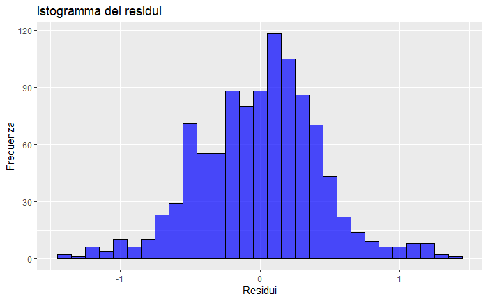

```r
res=residuals(model.6B)
ggplot(data.frame(res), aes(x = res)) +
  geom_histogram(binwidth = 0.1, fill = "blue", color = "black", alpha = 0.7) +
  labs(title = "Istogramma dei residui", x = "Residui", y = "Frequenza")
```

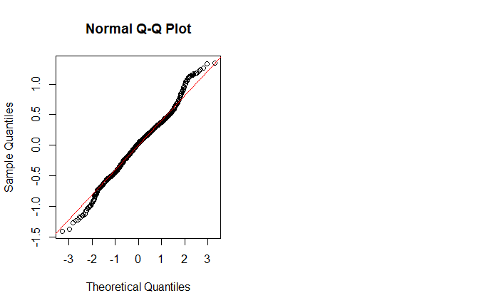

```r
par(mfrow=c(1,2))

qqnorm(res)
qqline(res, col = "red")
```

```r
shapiro.test(res)
```

```
    Shapiro-Wilk normality test

data:  res
W = 0.99159, p-value = 1.378e-05
```

```r
mod_ga<- gamlss(price~ 1+ pseed + purea + wage + pesticide + goutput + noutput + (1|Regione), family = GA, data =data_2) # Attenzione su data_2 non data scale
```

[output not shown]

```r
data_2 %>%
  group_by(Regione) %>%
  summarise(n_id_unici = n_distinct(id))
```

| Regione | n_id_unici |
| --- | --- |
| 1 | 19 |
| 2 | 24 |
| 3 | 37 |
| 4 | 33 |
| 5 | 22 |
| 6 | 36 |

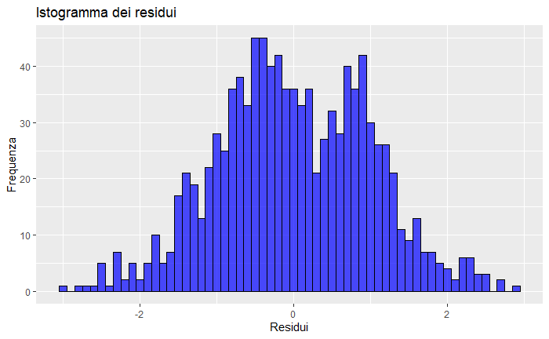

```r
res2=residuals(mod_ga)
ggplot(data.frame(res2), aes(x = res2)) +
  geom_histogram(binwidth = 0.1, fill = "blue", color = "black", alpha = 0.7) +
  labs(title = "Istogramma dei residui", x = "Residui", y = "Frequenza")
```

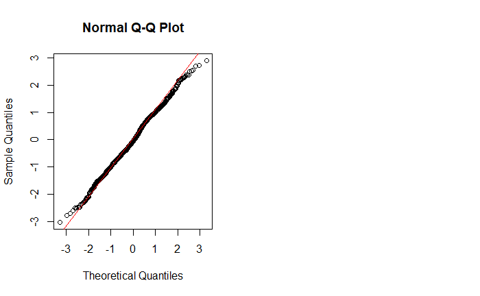

```r
par(mfrow=c(1,2))

qqnorm(res2)
qqline(res2, col = "red")
```

```r
shapiro.test(res2)
```

```
    Shapiro-Wilk normality test

data:  res2
W = 0.99702, p-value = 0.05268
```

```r
m = 80

# Crea la variabile categoriale usando cut()
data_2$wage_cat=  cut(
  data_2$wage,
  breaks = c(-Inf, m, Inf),
  labels = c(0, 1),
  right = FALSE  # In questo caso, l'intervallo non include il valore di soglia; se vuoi includere thresh nel secondo gruppo, rimuovi questo parametro o impostalo a TRUE
)

mod_ga.2<- gamlss(price~ 1+ pseed + goutput + noutput + varieties  + pphosph + bimas + wage_cat + (1|Regione), family = GA, data =data_2) # Attenzione su data_2 non data scale
```

```
GAMLSS-RS iteration 1: Global Deviance = 8082.404
GAMLSS-RS iteration 2: Global Deviance = 8082.404
```

```r
summary(mod_ga.2)
```

```
Family:  c("GA", "Gamma")

Call:  gamlss(formula = price ~ 1 + pseed + goutput + noutput +      varieties + pphosph + bimas + wage_cat + (1 | Regione),      family = GA, data = data_2)

Fitting method: RS()

------------------------------------------------------------------
Mu link function:  log
Mu Coefficients:
                 Estimate Std. Error t value Pr(>|t|)
(Intercept)     4.463e+00  6.831e-02  65.328  < 2e-16 ***
pseed           5.259e-04  1.245e-04   4.225 2.61e-05 ***
goutput        -1.597e-04  5.468e-05  -2.921 0.003564 **
noutput         1.864e-04  6.394e-05   2.914 0.003641 **
varietieshigh  -1.486e-01  1.183e-02 -12.555  < 2e-16 ***
varietiesmixed -8.564e-02  2.177e-02  -3.934 8.93e-05 ***
pphosph        -3.348e-03  8.677e-04  -3.858 0.000121 ***
bimasyes       -5.884e-02  1.727e-02  -3.408 0.000681 ***
bimasmixed     -5.083e-02  1.361e-02  -3.733 0.000199 ***
wage_cat1       7.335e-01  2.348e-02  31.233  < 2e-16 ***
---
Signif. codes:  0 ‘***’ 0.001 ‘**’ 0.01 ‘*’ 0.05 ‘.’ 0.1 ‘ ’ 1

------------------------------------------------------------------
Sigma link function:  log
Sigma Coefficients:
            Estimate Std. Error t value Pr(>|t|)
(Intercept)   -1.920      0.022  -87.26   <2e-16 ***
---
Signif. codes:  0 ‘***’ 0.001 ‘**’ 0.01 ‘*’ 0.05 ‘.’ 0.1 ‘ ’ 1

------------------------------------------------------------------
No. of observations in the fit:  1026
Degrees of Freedom for the fit:  11
      Residual Deg. of Freedom:  1015
                      at cycle:  2

Global Deviance:     8082.404
            AIC:     8104.404
            SBC:     8158.672
```

```r
res2=residuals(mod_ga.2)
```

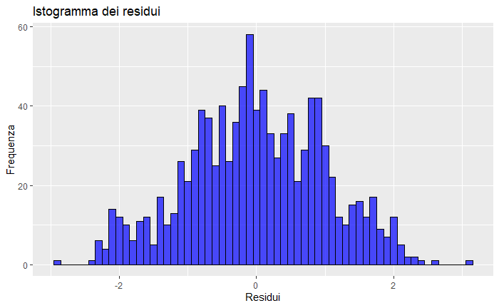

```r
res3=residuals(mod_ga.2)
ggplot(data.frame(res3), aes(x = res3)) +
  geom_histogram(binwidth = 0.1, fill = "blue", color = "black", alpha = 0.7) +
  labs(title = "Istogramma dei residui", x = "Residui", y = "Frequenza")
```

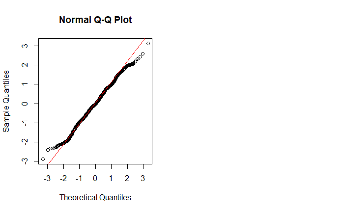

```r
par(mfrow=c(1,2))

qqnorm(res3)
qqline(res3, col = "red")
```

```r
shapiro.test(res3)
```

```
    Shapiro-Wilk normality test

data:  res3
W = 0.99529, p-value = 0.002935
```

```r
m = 80

# Crea la variabile categoriale usando cut()
data_2$wage_cat=  cut(
  data_2$wage,
  breaks = c(-Inf, m, Inf),
  labels = c(0, 1),
  right = FALSE  # In questo caso, l'intervallo non include il valore di soglia; se vuoi includere thresh nel secondo gruppo, rimuovi questo parametro o impostalo a TRUE
)

#mod_ga.3<- gamlss(price~ 1+ pseed  + pphosph + bimas + wage_cat + region + (1|id), family = GA, data =data_2) # Attenzione su data_2 non data scale
mod_ga.3<- lmer(price~ 1+  pphosph + bimas + wage_cat + (1+pseed|region),  data =data_2) # Attenzione su data_2 non data scale
```

```
Avvertimento: Model failed to converge with max|grad| = 1.59082 (tol = 0.002, component 1)
```

```r
summary(mod_ga.3)
```

```
Linear mixed model fit by REML. t-tests use Satterthwaite's method ['lmerModLmerTest']
Formula: price ~ 1 + pphosph + bimas + wage_cat + (1 + pseed | region)
   Data: data_2

REML criterion at convergence: 8024.7

Scaled residuals:
    Min      1Q  Median      3Q     Max
-4.5568 -0.4824 -0.0442  0.5406  4.0074

Random effects:
 Groups   Name        Variance  Std.Dev. Corr
 region   (Intercept)  43.04054  6.5605
          pseed         0.01471  0.1213  -0.72
 Residual             141.46178 11.8938
Number of obs: 1026, groups:  region, 6

Fixed effects:
              Estimate Std. Error         df t value Pr(>|t|)
(Intercept)   81.47695    6.03148  454.68653  13.509  < 2e-16 ***
pphosph       -0.22208    0.07626 1008.83440  -2.912  0.00367 **
bimasyes      -3.55512    1.52647 1009.86142  -2.329  0.02006 *
bimasmixed    -2.51406    1.10545 1010.45567  -2.274  0.02316 *
wage_cat1     64.49476    1.94851  999.72047  33.099  < 2e-16 ***
---
Signif. codes:  0 ‘***’ 0.001 ‘**’ 0.01 ‘*’ 0.05 ‘.’ 0.1 ‘ ’ 1

Correlation of Fixed Effects:
           (Intr) pphsph bimsys bmsmxd
pphosph    -0.945
bimasyes   -0.136  0.133
bimasmixed  0.015 -0.068  0.107
wage_cat1   0.673 -0.692 -0.077  0.152
optimizer (nloptwrap) convergence code: 0 (OK)
Model failed to converge with max|grad| = 1.59082 (tol = 0.002, component 1)
```

```r
res2=residuals(mod_ga.3)
```

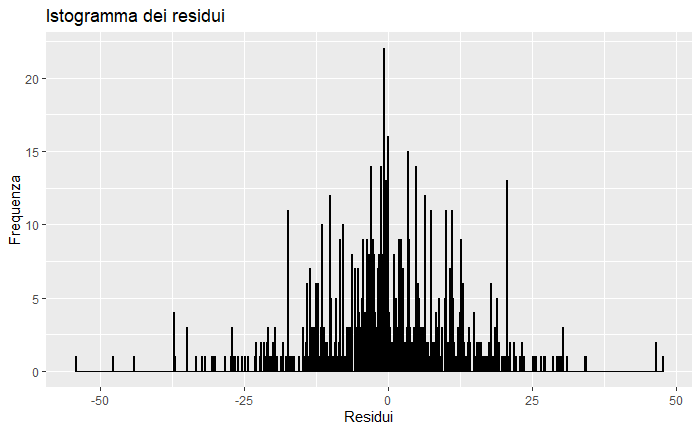

```r
res4=residuals(mod_ga.3)
ggplot(data.frame(res4), aes(x = res4)) +
  geom_histogram(binwidth = 0.1, fill = "blue", color = "black", alpha = 0.7) +
  labs(title = "Istogramma dei residui", x = "Residui", y = "Frequenza")
```

```r
#mod_st3 <- gamlss(price ~ 1 + pseed + pphosph + bimas + wage_cat + status ,random = ~1 | region,family = GA, data = data_2)
#mod_st4 <- gamlss(price ~ 1 + pseed + pphosph + bimas + wage_cat + status ,random = ~1 | region,family = LOGNO, data = data_2)
#mod_st3 <- gamlss(price ~ 1 + pseed + pphosph + bimas ,random = ~1 | region,family = GA, data = data_2)
#mod_st4 <- gamlss(price ~ 1 + pseed + pphosph + bimas ,random = ~1 | region,family = LOGNO, data = data_2)
mod_ga <- gamlss(price ~ 1 + pseed + goutput + noutput  + pphosph + bimas ,random = ~1 | region,family = GA, data = data_2)
```

```
GAMLSS-RS iteration 1: Global Deviance = 8854.446
GAMLSS-RS iteration 2: Global Deviance = 8854.446
```

```r
mod_ga_2 <- gamlss(price ~ 1 + pseed + goutput + noutput  + pphosph ,random = ~1 | region,family = GA, data = data_2)
```

```
GAMLSS-RS iteration 1: Global Deviance = 8901.944
GAMLSS-RS iteration 2: Global Deviance = 8901.944
```

```r
AIC(mod_ga,mod_ga_2)
```

|  | df | AIC |
| --- | --- | --- |
| mod_ga | 8 | 8870.446 |
| mod_ga_2 | 6 | 8913.944 |

```r
mod_logno <- gamlss(price ~ 1 + pseed + goutput + noutput  + pphosph + bimas ,random = ~1 | region,family = LOGNO, data = data_2)
```

```
GAMLSS-RS iteration 1: Global Deviance = 8839.463
GAMLSS-RS iteration 2: Global Deviance = 8839.463
```

```
          Summary of the Quantile Residuals
                           mean   =  -0.0003448251
                       variance   =  1.000923
               coef. of skewness  =  0.2813905
               coef. of kurtosis  =  3.350457
Filliben correlation coefficient  =  0.9969236
```

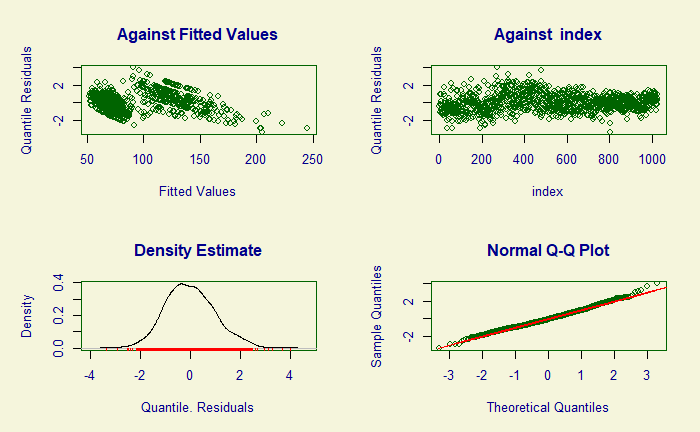

```r
a=AIC(mod_ga,mod_logno)
b=BIC(mod_ga,mod_logno)
plot(mod_ga, which = 1, main = "Gamma - Residui normalizzati")
```

```
          Summary of the Quantile Residuals
                           mean   =  -7.077304e-17
                       variance   =  1.000976
               coef. of skewness  =  0.1309473
               coef. of kurtosis  =  3.184053
Filliben correlation coefficient  =  0.9985666
```

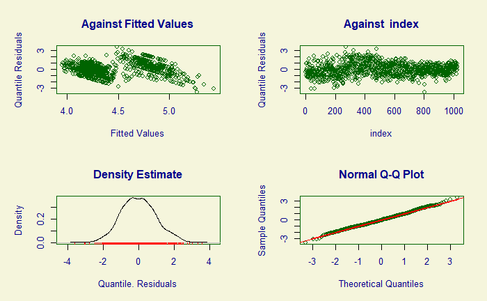

```r
plot(mod_logno, which = 1, main = "LOGNO - Residui normalizzati")
```

```r
cbind(a[2],b[2])
```

[output not shown]

```r
print("mod_ga")
```

```
[1] "mod_ga"
```

```r
summary(mod_ga)
```

```
Family:  c("GA", "Gamma")

Call:  gamlss(formula = price ~ 1 + pseed + goutput + noutput +      pphosph + bimas, family = GA, data = data_2, random = ~1 |      region)

Fitting method: RS()

------------------------------------------------------------------
Mu link function:  log
Mu Coefficients:
              Estimate Std. Error t value Pr(>|t|)
(Intercept)  2.749e+00  6.221e-02  44.192  < 2e-16 ***
pseed        2.857e-03  1.360e-04  21.010  < 2e-16 ***
goutput     -5.229e-04  7.504e-05  -6.969 5.74e-12 ***
noutput      6.216e-04  8.816e-05   7.050 3.30e-12 ***
pphosph      1.732e-02  8.513e-04  20.352  < 2e-16 ***
bimasyes    -4.823e-02  2.485e-02  -1.941   0.0526 .
bimasmixed  -1.354e-01  1.945e-02  -6.962 6.02e-12 ***
---
Signif. codes:  0 ‘***’ 0.001 ‘**’ 0.01 ‘*’ 0.05 ‘.’ 0.1 ‘ ’ 1

------------------------------------------------------------------
Sigma link function:  log
Sigma Coefficients:
            Estimate Std. Error t value Pr(>|t|)
(Intercept) -1.54739    0.02191  -70.63   <2e-16 ***
---
Signif. codes:  0 ‘***’ 0.001 ‘**’ 0.01 ‘*’ 0.05 ‘.’ 0.1 ‘ ’ 1

------------------------------------------------------------------
No. of observations in the fit:  1026
Degrees of Freedom for the fit:  8
      Residual Deg. of Freedom:  1018
                      at cycle:  2

Global Deviance:     8854.446
            AIC:     8870.446
            SBC:     8909.914
```

```r
print("mod_logno")
```

```
[1] "mod_logno"
```

```r
summary(mod_logno)
```

```
Family:  c("LOGNO", "Log Normal")

Call:  gamlss(formula = price ~ 1 + pseed + goutput + noutput +      pphosph + bimas, family = LOGNO, data = data_2,      random = ~1 | region)

Fitting method: RS()

------------------------------------------------------------------
Mu link function:  identity
Mu Coefficients:
              Estimate Std. Error t value Pr(>|t|)
(Intercept)  2.754e+00  6.207e-02  44.364  < 2e-16 ***
pseed        2.691e-03  1.245e-04  21.612  < 2e-16 ***
goutput     -5.131e-04  7.516e-05  -6.826 1.50e-11 ***
noutput      6.108e-04  8.805e-05   6.937 7.09e-12 ***
pphosph      1.719e-02  8.409e-04  20.439  < 2e-16 ***
bimasyes    -3.838e-02  2.501e-02  -1.535    0.125
bimasmixed  -1.298e-01  1.936e-02  -6.704 3.35e-11 ***
---
Signif. codes:  0 ‘***’ 0.001 ‘**’ 0.01 ‘*’ 0.05 ‘.’ 0.1 ‘ ’ 1

------------------------------------------------------------------
Sigma link function:  log
Sigma Coefficients:
            Estimate Std. Error t value Pr(>|t|)
(Intercept) -1.54715    0.02208  -70.08   <2e-16 ***
---
Signif. codes:  0 ‘***’ 0.001 ‘**’ 0.01 ‘*’ 0.05 ‘.’ 0.1 ‘ ’ 1

------------------------------------------------------------------
No. of observations in the fit:  1026
Degrees of Freedom for the fit:  8
      Residual Deg. of Freedom:  1018
                      at cycle:  2

Global Deviance:     8839.463
            AIC:     8855.463
            SBC:     8894.931
```

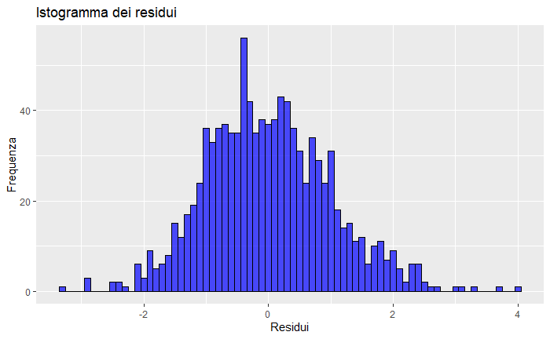

```r
res5=residuals(mod_ga)
ggplot(data.frame(res5), aes(x = res5)) +
  geom_histogram(binwidth = 0.1, fill = "blue", color = "black", alpha = 0.7) +
  labs(title = "Istogramma dei residui", x = "Residui", y = "Frequenza")
```

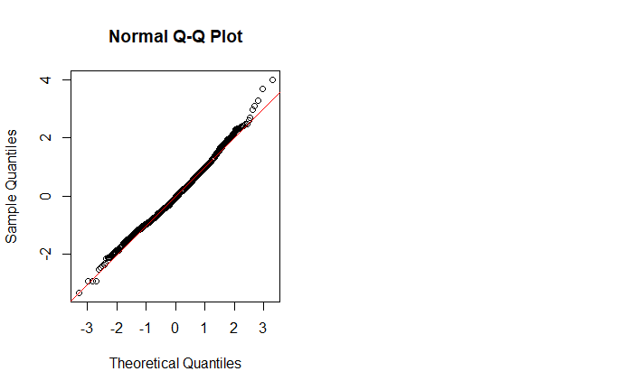

```r
par(mfrow=c(1,2))

qqnorm(res5)
qqline(res5, col = "red")
```

```r
shapiro.test(res5)
```

```
    Shapiro-Wilk normality test

data:  res5
W = 0.99402, p-value = 0.0004067
```

# Consideraizoni

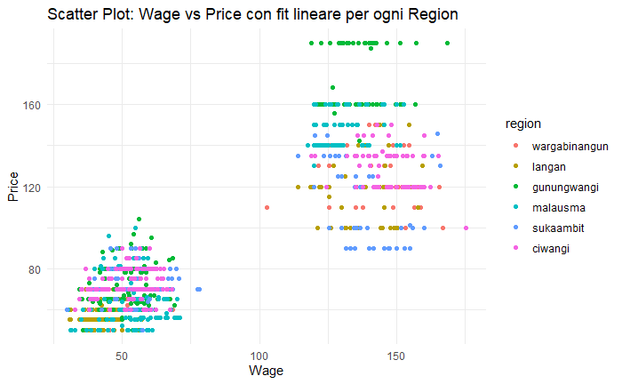

```r
# Supponendo che il tuo dataset sia salvato in un oggetto chiamato 'dataset'
ggplot(data, aes(x = wage, y = price, color = region)) +
  geom_point() +                         # Aggiunge i punti del grafico
  labs(
    x = "Wage",
    y = "Price",
    title = "Scatter Plot: Wage vs Price con fit lineare per ogni Region"
  ) +
  theme_minimal()  # Opzionale, per un tema più pulito
```

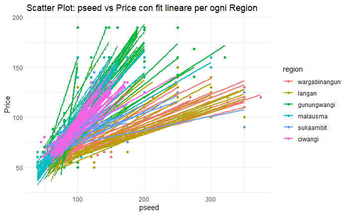

```r
# Supponendo che il tuo dataset sia salvato in un oggetto chiamato 'dataset'
ggplot(data, aes(x = pseed, y = price, group = id, color = region)) +
  geom_point() +                         # Aggiunge i punti del grafico
  geom_smooth(method = "lm", se = FALSE) + # Aggiunge la linea di regressione lineare per ogni region
  labs(
    x = "pseed",
    y = "Price",
    title = "Scatter Plot: pseed vs Price con fit lineare per ogni Region"
  ) +
  theme_minimal()  # Opzionale, per un tema più pulito
```

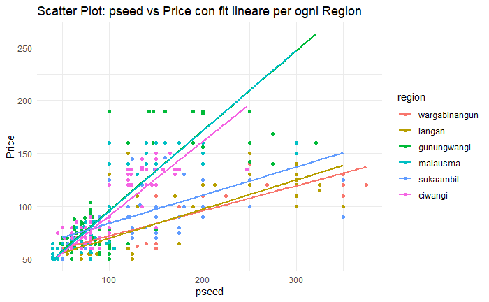

```r
# Supponendo che il tuo dataset sia salvato in un oggetto chiamato 'dataset'
ggplot(data, aes(x = pseed, y = price, color = region)) +
  geom_point() +                         # Aggiunge i punti del grafico
  geom_smooth(method = "lm", se = FALSE) + # Aggiunge la linea di regressione lineare per ogni region
  labs(
    x = "pseed",
    y = "Price",
    title = "Scatter Plot: pseed vs Price con fit lineare per ogni Region"
  ) +
  theme_minimal()  # Opzionale, per un tema più pulito
```

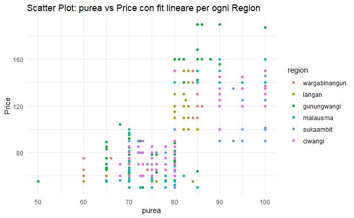

```r
# Supponendo che il tuo dataset sia salvato in un oggetto chiamato 'dataset'
ggplot(data, aes(x = purea, y = price, color = region)) +
  geom_point() +                         # Aggiunge i punti del grafico
  labs(
    x = "purea",
    y = "Price",
    title = "Scatter Plot: purea vs Price con fit lineare per ogni Region"
  ) +
  theme_minimal()  # Opzionale, per un tema più pulito
```

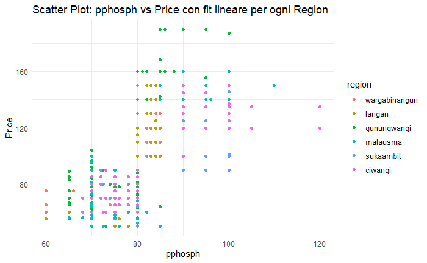

```r
# Supponendo che il tuo dataset sia salvato in un oggetto chiamato 'dataset'
ggplot(data, aes(x = pphosph, y = price, color = region)) +
  geom_point() +                         # Aggiunge i punti del grafico
  labs(
    x = "pphosph",
    y = "Price",
    title = "Scatter Plot: pphosph vs Price con fit lineare per ogni Region"
  ) +
  theme_minimal()  # Opzionale, per un tema più pulito
```

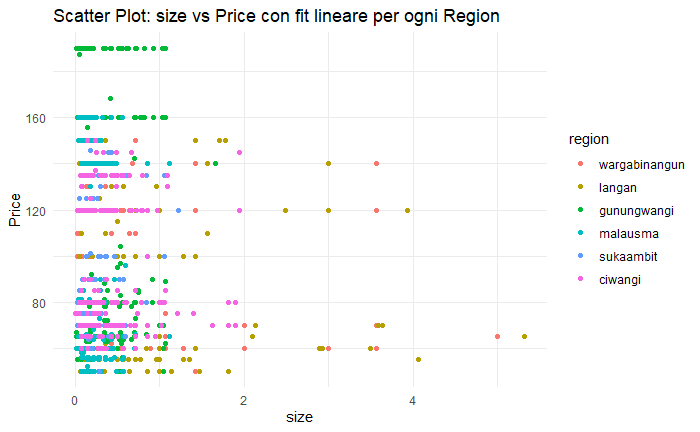

```r
# Supponendo che il tuo dataset sia salvato in un oggetto chiamato 'dataset'
ggplot(data, aes(x = size, y = price, color = region)) +
  geom_point() +                         # Aggiunge i punti del grafico
  labs(
    x = "size",
    y = "Price",
    title = "Scatter Plot: size vs Price con fit lineare per ogni Region"
  ) +
  theme_minimal()  # Opzionale, per un tema più pulito
```

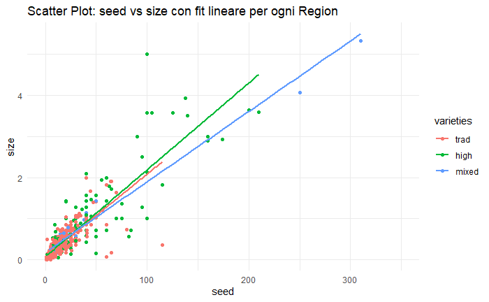

```r
# Supponendo che il tuo dataset sia salvato in un oggetto chiamato 'dataset'
ggplot(data, aes(x = seed, y = size, color = varieties)) +
  geom_point() +                         # Aggiunge i punti del grafico
  labs(
    x = "seed",
    y = "size",
    title = "Scatter Plot: seed vs size con fit lineare per ogni Region"
  ) +
  geom_smooth(method = "lm", se = FALSE) +
  xlim(0, 350) +
  theme_minimal()  # Opzionale, per un tema più pulito
```